# 第二讲 线性回归

## 1 前言

下面不详述违反各项经典假设的原因及可能造成的后果，请参见计量经济学或者其它相关书籍

关于偏残差系数的数理意义请参考：赵松山《关于偏残差系数的讨论》，在这里不展开讨论

## 2 线性回归

### 2.1 简单线性回归

```r
#Boston数据集在MASS包里面
library(MASS)
#fix(Boston)  #看一下Boston是一张怎样的数据表
#names(Boston)#看一下Boston数据表中的各个变量名称

#用lm.fit2.1 <-lm(medv ~ lstat, data = Boston)可以得到跟以下两句同样的结果
attach(Boston)
lm.fit2.1 <- lm(medv ~ lstat) #得到线性回归函数

lm.fit2.1 #系数
```

```
##
## Call:
## lm(formula = medv ~ lstat)
##
## Coefficients:
## (Intercept)        lstat
##       34.55        -0.95
```

```r
summary(lm.fit2.1) #查看置信区间，p值，标准误，R^2，F统计量
```

```
##
## Call:
## lm(formula = medv ~ lstat)
##
## Residuals:
##     Min      1Q  Median      3Q     Max
## -15.168  -3.990  -1.318   2.034  24.500
##
## Coefficients:
##             Estimate Std. Error t value Pr(>|t|)
## (Intercept) 34.55384    0.56263   61.41   <2e-16 ***
## lstat       -0.95005    0.03873  -24.53   <2e-16 ***
## ---
## Signif. codes:  0 '***' 0.001 '**' 0.01 '*' 0.05 '.' 0.1 ' ' 1
##
## Residual standard error: 6.216 on 504 degrees of freedom
## Multiple R-squared:  0.5441, Adjusted R-squared:  0.5432
## F-statistic: 601.6 on 1 and 504 DF,  p-value: < 2.2e-16
```

**结果解读：**星号个数表示显著性的强弱，“*”越多表示显著性越强

```r
confint(lm.fit2.1) #得到系数估计值的置信区间
```

```
##                 2.5 %     97.5 %
## (Intercept) 33.448457 35.6592247
## lstat       -1.026148 -0.8739505
```

```r
predict(lm.fit2.1, data.frame(lstat = (c(2, 6, 9))), interval = "confidence") #用lstat预测medv得到的置信区间
```

```
##        fit      lwr      upr
## 1 32.65374 31.67807 33.62942
## 2 28.85354 28.11121 29.59588
## 3 26.00340 25.39347 26.61332
```

```r
predict(lm.fit2.1, data.frame(lstat = (c(2, 6, 9))), interval = "prediction") #用lstat预测medv得到的预测区间
```

```
##        fit      lwr      upr
## 1 32.65374 20.40284 44.90465
## 2 28.85354 16.61901 41.08808
## 3 26.00340 13.77618 38.23061
```

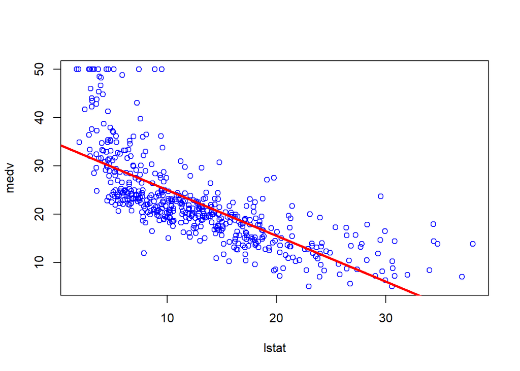

```r
#画出函数拟合图
plot(lstat, medv, col="blue")
abline(lm.fit2.1, lwd = 3, col = "red")
```

**注意：**lm（应变量~自变量），plot（自变量，应变量），abline()不能单独使用，上面必有一行画图的命令